# Writing

## Topics

- Markdown syntax

## Markdown syntax

When writing the body of your document, you will use the [Markdown](https://daringfireball.net/projects/markdown/syntax) format.

> Markdown is a lightweight markup language that you can use to add formatting elements to plaintext text documents. - [*Markdown Guide*](https://www.markdownguide.org/getting-started/)

## A World With Markdown

**Code**

```markdown
Welcome to my markdown document.
We can have **bold**, _italic_,
***bold and italics*** text.
Also, we have:

- An
- Unordered
- List

Not bad right?
```

**Output**

Welcome to my markdown document. We can have **bold**, *italic*, *bold and italics* text. Also, we have:

- An
- Unordered
- List

Not bad right?

Markdown is the

**lingua franca**

to creating any kind of document

## Markdown in the wild: Reddit

[figure not shown]

Writing a post using markdown on [Stanford’s Subreddit](https://reddit.com/r/stanford)

## Markdown in the wild: GitHub

[figure not shown]

Writing an issue using markdown on [GitHub](https://github.com)

## Markdown quick reference in RStudio

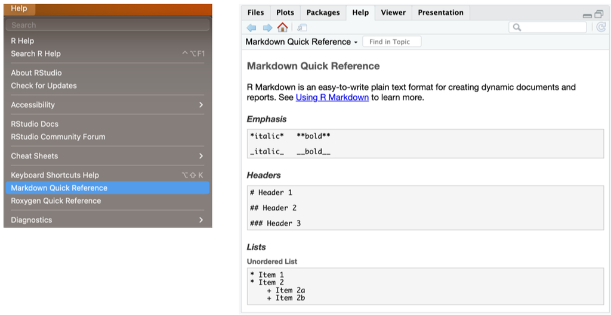

Accessing the “Markdown Quick Reference” Guide inside of RStudio

## Learning Markdown

You can familiarize yourself with Markdown in a couple of minutes using the following link: https://www.markdownguide.org/cheat-sheet/.

You can also use the **Visual Editor** in [VS Code](https://quarto.org/docs/visual-editor/vscode/), [RStudio](https://quarto.org/docs/visual-editor/), or [Positron](https://positron.posit.co/) to see Markdown syntax previewed in it’s final format as you write. The Visual Editor also has some common Word-like shortcuts, such as `Ctrl + B` to make text bold.

## Markdown Sneak Peek: Text Formatting

Markdown Syntax

Output

```
*italics* and **bold**
```

*italics* and **bold**

```
superscript^2^ / subscript~2~
```

superscript<sup>2</sup> / subscript<sub>2</sub>

```
~~strikethrough~~
```

strikethrough

```
`verbatim code`
```

`verbatim code`

## Markdown sneak peek: Headers

Markdown Syntax

Output

```
# Header 1
```

# Header 1

```
## Header 2
```

## Header 2

```
### Header 3
```

### Header 3

```
#### Header 4
```

#### Header 4

## Markdown sneak peek: Quotes

**Code**

```markdown
> "Never gonna give you up,
>  never gonna let you down..."
>
> --- Rick Astley
```

**Output**

> “Never gonna give you up, never gonna let you down…”

> — Rick Astley

## Markdown sneak peek: Math

**Code**

```markdown
Inline math:
$a^2 + b^2 = c^2$

Display math (centered math):
$$1 - x = y$$
```

**Output**

Inline math: $a^2 + b^2 = c^2$

Display math (centered math):
$$1 - x = y$$

## Markdown sneak peek: Lists unordered

**Code**

```markdown
My **un**ordered list:

- Write Selection Simulation
- Conference Abstracts
     - UseR
     - Learning at Scale
```

**Output**

My **un**ordered list:

- Write Selection Simulation
- Conference Abstracts
  - UseR
  - Learning at Scale

## Markdown sneak peek: Lists ordered

**Code**

```markdown
My **ordered** list:

1. Apples
1. Bananas
1. Chobani
    1. Pineapple
    1. Everything else
```

**Output**

My **ordered** list:

1. Apples
2. Bananas
3. Chobani
   1. Pineapple
   2. Everything else

## Markdown sneak peek: Summary

**Important**

Make sure a new line (space) exists between text and the first list item. For sublists or nested lists, indent **four spaces** to create a new level in the list.

**Tip**

To simplify ordered lists and allow for moving items in the list around, use `1.` for each item. If a list needs to be broken, numbering is only continued if each entry is labeled using `1.`, `2.`, `3.`, … format.

## Markdown sneak peek: Tables

**Code**

```markdown
| Left                    | Center          | Right   |
|-------------------------|:---------------:|--------:|
| Hey, check it out       | Colons provide  |    873  |
| its **Markdown**        | alignment thus  |   1000  |
| right in the table      | *centered* text |         |
```

**Output**

| Left | Center | Right |
| --- | --- | --- |
| Hey, check it out | Colons provide | 873 |
| its **Markdown** | alignment thus | 1000 |
| right in the table | *centered* text |  |

## Table: Tip

**Tip**

`Visual` mode provides a [`Table` menu](https://quarto.org/docs/visual-editor/#editor-toolbar) to setup [quarto tables](https://quarto.org/docs/authoring/tables.html) or use the [table generator](https://www.tablesgenerator.com/markdown_tables) website.

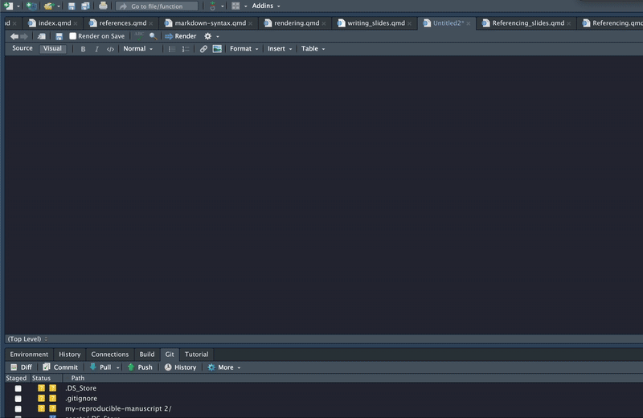

## Markdown sneak peek: Links

```markdown
You can embed [named hyperlinks](https://quarto.org/)
```

You can embed [named hyperlinks](https://quarto.org/)

```markdown
Simply a direct url like <https://quarto.org/>
```

Simply a direct url like https://quarto.org/

```markdown
Links to [other places](#quarto-anatomy) in the document.
```

Links to other places in the document.

## Markdown sneak peek: Links

```markdown
Or embed an image:
![penguins](https://allisonhorst.github.io/palmerpenguins/reference/figures/lter_penguins.png)
```

[output not shown]

Or embed an image:

## Callout blocks

- Call-out blocks highlight sections of text that interrupt the flow of your regular text. Maybe it’s a definition, a warning, or a sidenote
- When rendering your document to HTML, callout blocks are interactive and can be collapsed and opened.

  **My First Callout Block!**

  Say things here

## Callout blocks

**Note**

Note that there are five types of callouts, including: `note`, `tip`, `warning`, `caution`, and `important`.

**Warning**

Callouts provide a simple way to attract attention, for example, to this warning.

**This is important**

Danger, callouts will really improve your writing.

**Tip with caption**

Run this first

**Caution, under construction**

Here is something under construction